# Homework 03

## Question 1: Build an `explain-to-me` skill

Create a small skill named `explain-to-me` that helps you understand a homework question.

1. Design your `SKILL.md` file so that, when you explicitly ask your agent to use the skill to read a homework question, the agent communicates with you and explains what the question is asking.
2. Keep the skill file short. It should contain a few useful rules, instructions, and a clear statement of your intent. For example, you may ask the agent to explain the goal of the question, clarify what work is required, and point you to an appropriate section of the Week 3 lectures: [Ridge Regression: Stability Through Shrinkage](https://teazrq.github.io/stat432rpy/topics/ridge-regression/ridge-regression.html) or [From a Penalized Objective to a Fitted Ridge Model](https://teazrq.github.io/stat432rpy/topics/ridge-regression/optimization-and-cross-validation.html). The skill should help you understand the question without completing the solution for you.
3. Create the skill yourself or with the help of AI. Save it as `explain-to-me/SKILL.md`. Then ask your AI agent to install the skill using its normal skill-installation method. Test it by explicitly asking the agent to use `explain-to-me` to read and explain Question 2.
4. If the skill does not work well, or if it begins to disturb your usual workflow, ask your agent to remove the installed skill. You may revise and reinstall it if you wish.
5. In all cases, append the complete contents of your developed `explain-to-me/SKILL.md` file at the end of your Homework 3 submission under the heading **`explain-to-me` skill**.

### Solution

I saved the skill in `explain-to-me/SKILL.md` and installed the same file in my Codex skills directory. I made the activation rule explicit so that an ordinary request to solve homework does not trigger it.

For the test, I asked the agent to use the skill to explain Question 2. It summarized the purpose of the simulation, separated the requested work in parts (a)–(c), and clarified what had to stay fixed across repetitions. It also linked the scaling section of the ridge lecture, suggested generating and standardizing $\mathbf X$ as the first step, and asked which part I still found confusing. It did not calculate the simulation results or write code. The complete skill used for this test is included at the end.

## Question 2: Ridge regression with nearly collinear predictors

Let $n=100$. Generate mutually independent standard normal random variables

$$L_i, U_{i1}, U_{i2}, X_{i3}, X_{i4},
\qquad i=1,\ldots,n,$$

and define

$$X_{i1}=L_i+0.04U_{i1},
\qquad
X_{i2}=L_i+0.04U_{i2}.$$

Center and standardize each column of $\mathbf X$ to have mean zero and average squared value one, following the [lecture’s scaling convention](https://teazrq.github.io/stat432rpy/topics/ridge-regression/ridge-regression.html#put-every-covariate-on-a-common-scale).

Continue to use $\mathbf X\in\mathbb R^{n\times p}$ for the standardized matrix and keep it fixed throughout the question, where $p=4$ is the number of predictors. The unpenalized intercept gives $p+1=5$ total fitted coefficients. Let

$$\boldsymbol\beta
=
(1.5,1.5,1,0)^{\mathsf T},
\qquad
\boldsymbol\mu
=
\mathbf X\boldsymbol\beta.$$

Generate a training response and an independent test response at the same predictor values:

$$\begin{aligned}
\mathbf y
&=
\boldsymbol\mu+\boldsymbol\epsilon,\\
\mathbf y^*
&=
\boldsymbol\mu+\boldsymbol\epsilon^*,
\end{aligned}$$

where

$$\boldsymbol\epsilon,
\boldsymbol\epsilon^*
\overset{\mathrm{ind}}{\sim}
\mathcal N_n(\mathbf0,\mathbf I_n).$$

Center the training response as $\widetilde{\mathbf y}=\mathbf y-\bar y\mathbf1_n$. For each $\lambda\in\{0,0.02,0.2\}$, fit the slopes using the lecture’s ridge formula:

$$\widehat{\boldsymbol\beta}_\lambda
=
\left(\mathbf X^{\mathsf T}\mathbf X+n\lambda\mathbf I_p\right)^{-1}
\mathbf X^{\mathsf T}\widetilde{\mathbf y}.$$

The unpenalized intercept is $\widehat\beta_0=\bar y$; add this training mean back when predicting either response. The case $\lambda=0$ is ordinary least squares. Use seed `43231` before generating the design and responses. R and Python use different random-number generators, so their exact numerical results need not agree.

1. Generate $\mathbf X$ once. Report the correlation between its first two columns and its largest and smallest singular values. Use these quantities to explain why the estimator contrast $\widehat\beta_1-\widehat\beta_2$ should be much more variable than $\widehat\beta_1+\widehat\beta_2$.
2. Independently repeat the generation of $\mathbf y$ and $\mathbf y^*$, followed by all three fits, 200 times while keeping $\mathbf X$ fixed. Draw the training and test noise inside each repetition, then reuse that realized pair for all three values of $\lambda$. For each value of $\lambda$, report the empirical mean and standard deviation of

$$\widehat\beta_1,
\quad
\widehat\beta_2,
\quad
\widehat\beta_1+\widehat\beta_2,
\quad
\widehat\beta_1-\widehat\beta_2.$$

Also report the average training MSE and the average test MSE calculated from the independent test response, where

$$\operatorname{MSE}_{\mathrm{test}}
=
\frac{1}{n}
\left\lVert
\mathbf y^*
-
\widehat\beta_0\mathbf1_n
-
\mathbf X\widehat{\boldsymbol\beta}
\right\rVert_2^2.$$

3. Interpret the coefficient estimates and test MSE using bias and variance. Explain why ridge can substantially stabilize the individual coefficients without producing an equally large change in the fitted values.

### Solution

#### a.

I generate and standardize the predictors before the simulation loop, so every repetition uses the same design. The expression `np.sqrt(np.mean(X_centered**2, axis=0))` gives the required divisor-$n$ scale. Inside a repetition, one training/test response pair is shared by all three penalties.

**Show the workflow**

```python
import numpy as np
import pandas as pd
from IPython.display import display

rng = np.random.default_rng(43231)
n, p, repetitions = 100, 4, 200

# Generate the predictor design once.
L = rng.normal(size=n)
U1 = rng.normal(size=n)
U2 = rng.normal(size=n)
X = np.column_stack(
    (L + 0.04 * U1, L + 0.04 * U2, rng.normal(size=n), rng.normal(size=n))
)

X_centered = X - X.mean(axis=0)
scales = np.sqrt(np.mean(X_centered**2, axis=0))
X = X_centered / scales

beta = np.array([1.5, 1.5, 1.0, 0.0])
mu = X @ beta
lambda_grid = np.array([0.0, 0.02, 0.2])

singular_values = np.linalg.svd(X, compute_uv=False)
design_summary = pd.DataFrame(
    {
        "quantity": [
            "correlation(X1, X2)",
            "largest singular value",
            "smallest singular value",
        ],
        "value": [
            np.corrcoef(X[:, 0], X[:, 1])[0, 1],
            singular_values.max(),
            singular_values.min(),
        ],
    }
)
display(
    design_summary.style
    .format({"value": "{:.5f}"})
    .hide(axis="index")
    .set_caption("Fixed-design diagnostics")
)

# Axes are repetition, coefficient, and penalty.
beta_hat = np.empty((repetitions, p, len(lambda_grid)))
train_mse = np.empty((repetitions, len(lambda_grid)))
test_mse = np.empty((repetitions, len(lambda_grid)))

for k in range(repetitions):
    # This one realized response pair is reused for all three penalties.
    y = mu + rng.normal(size=n)
    y_test = mu + rng.normal(size=n)
    y_centered = y - y.mean()

    for ell, lam in enumerate(lambda_grid):
        beta_hat[k, :, ell] = np.linalg.solve(
            X.T @ X + n * lam * np.eye(p),
            X.T @ y_centered,
        )
        y_hat = y.mean() + X @ beta_hat[k, :, ell]
        train_mse[k, ell] = np.mean((y - y_hat) ** 2)
        test_mse[k, ell] = np.mean((y_test - y_hat) ** 2)

coefficient_rows = []
for ell, lam in enumerate(lambda_grid):
    b1 = beta_hat[:, 0, ell]
    b2 = beta_hat[:, 1, ell]
    coefficient_rows.append(
        {
            "lambda": lam,
            "mean beta1": b1.mean(),
            "SD beta1": b1.std(ddof=1),
            "mean beta2": b2.mean(),
            "SD beta2": b2.std(ddof=1),
            "mean sum": (b1 + b2).mean(),
            "SD sum": (b1 + b2).std(ddof=1),
            "mean difference": (b1 - b2).mean(),
            "SD difference": (b1 - b2).std(ddof=1),
        }
    )

coefficient_summary = pd.DataFrame(coefficient_rows)
error_summary = pd.DataFrame(
    {
        "lambda": lambda_grid,
        "average training MSE": train_mse.mean(axis=0),
        "average test MSE": test_mse.mean(axis=0),
    }
)

display(
    coefficient_summary.style
    .format(precision=3)
    .hide(axis="index")
    .set_caption("Coefficient summaries across 200 repetitions")
)
display(
    error_summary.style
    .format(precision=3)
    .hide(axis="index")
    .set_caption("Average training and independent-test error")
)
```

Table 1: Fixed-design diagnostics

| quantity | value |
| --- | --- |
| correlation(X1, X2) | 0.99833 |
| largest singular value | 14.17296 |
| smallest singular value | 0.40609 |

Table 2: Coefficient summaries across 200 repetitions

| lambda | mean beta1 | SD beta1 | mean beta2 | SD beta2 | mean sum | SD sum | mean difference | SD difference |
| --- | --- | --- | --- | --- | --- | --- | --- | --- |
| 0.000 | 1.290 | 1.795 | 1.701 | 1.798 | 2.992 | 0.105 | -0.411 | 3.592 |
| 0.020 | 1.465 | 0.145 | 1.497 | 0.148 | 2.961 | 0.104 | -0.032 | 0.274 |
| 0.200 | 1.355 | 0.049 | 1.359 | 0.050 | 2.715 | 0.095 | -0.004 | 0.029 |

Table 3: Average training and independent-test error

| lambda | average training MSE | average test MSE |
| --- | --- | --- |
| 0.000 | 0.949 | 1.038 |
| 0.020 | 0.960 | 1.029 |
| 0.200 | 1.064 | 1.125 |

The sample correlation is $0.99833$, so the first two columns are almost the same. The largest singular value is $14.17296$, while the smallest is only $0.40609$; this large gap identifies a direction of the design with very little information. To see which coefficient combination is affected, write

$$\beta_1X_1+\beta_2X_2
=
\frac{\beta_1+\beta_2}{2}(X_1+X_2)
+
\frac{\beta_1-\beta_2}{2}(X_1-X_2).$$

The latent term $L$ adds in $X_1+X_2$, but it nearly disappears from $X_1-X_2$. The difference is mostly the small $0.04U$ perturbations, so it is the weak direction. Noise can then move $\widehat\beta_1$ and $\widehat\beta_2$ far in opposite directions without changing the fitted response very much. This makes $\widehat\beta_1-\widehat\beta_2$ unstable even though $\widehat\beta_1+\widehat\beta_2$ is estimated precisely.

#### b.

For OLS, the empirical standard deviation of the difference is $3.592$, compared with only $0.105$ for the sum. At $\lambda=0.02$, these standard deviations are $0.274$ and $0.104$, and average test MSE falls slightly from $1.038$ to $1.029$. With $\lambda=0.2$, the difference has standard deviation $0.029$, but the mean sum is pulled down to $2.715$ and average test MSE rises to $1.125$. The separate OLS means, $1.290$ and $1.701$, do not have to equal $1.5$ in only 200 repetitions. The clearer pattern is their large variability together with a mean sum, $2.992$, close to its true value $3$.

#### c.

Conditional on the fixed design, OLS has no shrinkage bias, but it pays for this with very high variance in the nearly unidentified difference direction. The moderate penalty removes much of that variance while barely changing the well-estimated sum, which explains its small improvement in test MSE.

The larger penalty stabilizes the coefficients even more, but now the added bias is visible in the mean sum and outweighs the variance reduction for prediction. Because $X_1\approx X_2$, opposite changes in the two slopes mostly cancel in $\mathbf X\widehat{\boldsymbol\beta}$. The individual slopes can look quite different across fits even when their fitted values remain similar.

## Question 3: What does ridge regression shrink?

Let $\mathbf X\in\mathbb R^{n\times p}$ be a centered predictor matrix, and let $\widetilde{\mathbf y}\in\mathbb R^n$ be the centered response. Use the supplied predictor scales for this algebraic question; the columns need not have unit variance. Here $p$ counts predictors, $\boldsymbol\beta\in\mathbb R^p$ contains their slopes, and $p+1$ counts all fitted coefficients, including the separately fitted, unpenalized intercept. Ridge regression minimizes

$$L_\lambda(\boldsymbol\beta)
=
\frac{1}{2n}
\left\lVert
\widetilde{\mathbf y}-\mathbf X\boldsymbol\beta
\right\rVert_2^2
+
\frac{\lambda}{2}
\lVert\boldsymbol\beta\rVert_2^2.$$

1. Derive the ridge normal equation

$$\left(
\mathbf X^{\mathsf T}\mathbf X
+n\lambda\mathbf I_p
\right)
\widehat{\boldsymbol\beta}_\lambda
=
\mathbf X^{\mathsf T}\widetilde{\mathbf y}.$$

Explain why it has a unique solution whenever $\lambda>0$, even if $\mathbf X$ is rank deficient or $p>n$.

2. Let

$$\mathbf X
=
\mathbf U_r\mathbf D_r\mathbf V_r^{\mathsf T}$$

be a compact singular value decomposition, where $r=\operatorname{rank}(\mathbf X)$, $\mathbf U_r\in\mathbb R^{n\times r}$, $\mathbf D_r\in\mathbb R^{r\times r}$, and $\mathbf V_r\in\mathbb R^{p\times r}$. Show that ridge multiplies the fitted response component in the $j$th left singular-vector direction, for $j=1,\ldots,r$, by

$$\rho_j(\lambda)
=
\frac{d_j^2}{d_j^2+n\lambda}.$$

Suppose $n=100$, $\lambda=0.01$, and the nonzero singular values are

$$d_1=10,
\qquad
d_2=2,
\qquad
d_3=0.2.$$

Calculate the three shrinkage factors and the total effective degrees of freedom, including the unpenalized intercept:

$$\operatorname{df}_{\mathrm{eff}}(\lambda)
=
1+\sum_{j=1}^3\rho_j(\lambda).$$

3. Which direction receives the strongest shrinkage? Explain why shrinking this direction can reduce prediction variance. Under what circumstance could the same shrinkage produce substantial prediction bias?

### Solution

#### a.

Writing the squared norm as an inner product makes both derivatives visible:

$$L_\lambda(\boldsymbol\beta)
=
\frac{1}{2n}
(\widetilde{\mathbf y}-\mathbf X\boldsymbol\beta)^{\mathsf T}
(\widetilde{\mathbf y}-\mathbf X\boldsymbol\beta)
+
\frac{\lambda}{2}\boldsymbol\beta^{\mathsf T}\boldsymbol\beta.$$

The residual term contributes $-(1/n)\mathbf X^{\mathsf T}(\widetilde{\mathbf y}-\mathbf X\boldsymbol\beta)$, while the penalty contributes $\lambda\boldsymbol\beta$. Hence

$$\nabla L_\lambda(\boldsymbol\beta)
=
-\frac{1}{n}\mathbf X^{\mathsf T}
(\widetilde{\mathbf y}-\mathbf X\boldsymbol\beta)
+\lambda\boldsymbol\beta.$$

Setting the gradient equal to zero at $\widehat{\boldsymbol\beta}_\lambda$ gives

$$\frac{1}{n}\mathbf X^{\mathsf T}\mathbf X
\widehat{\boldsymbol\beta}_\lambda
+\lambda\widehat{\boldsymbol\beta}_\lambda
=
\frac{1}{n}\mathbf X^{\mathsf T}\widetilde{\mathbf y}.$$

After multiplying by $n$ and collecting the two terms containing $\widehat{\boldsymbol\beta}_\lambda$,

$$(\mathbf X^{\mathsf T}\mathbf X+n\lambda\mathbf I_p)
\widehat{\boldsymbol\beta}_\lambda
=
\mathbf X^{\mathsf T}\widetilde{\mathbf y}.$$

For every nonzero $\mathbf a\in\mathbb R^p$,

$$\mathbf a^{\mathsf T}
(\mathbf X^{\mathsf T}\mathbf X+n\lambda\mathbf I_p)
\mathbf a
=
\lVert\mathbf X\mathbf a\rVert_2^2
+n\lambda\lVert\mathbf a\rVert_2^2
>0$$

when $\lambda>0$. The second term is strictly positive even if $\mathbf X\mathbf a=\mathbf0$, so the whole matrix is positive definite and invertible. This gives a unique ridge solution even when rank deficiency makes the OLS solution nonunique.

#### b.

The compact SVD implies

$$\mathbf X^{\mathsf T}\mathbf X
=
\mathbf V_r\mathbf D_r^2\mathbf V_r^{\mathsf T},
\qquad
\mathbf X^{\mathsf T}\widetilde{\mathbf y}
=
\mathbf V_r\mathbf D_r\mathbf U_r^{\mathsf T}\widetilde{\mathbf y}.$$

Substituting these identities into the normal equation and working in the right-singular-vector basis gives

$$\widehat{\boldsymbol\beta}_\lambda
=
\mathbf V_r
(\mathbf D_r^2+n\lambda\mathbf I_r)^{-1}
\mathbf D_r\mathbf U_r^{\mathsf T}\widetilde{\mathbf y}.$$

If $r<p$, there are also coefficient directions in the null space of $\mathbf X$. Moving along one of them leaves $\mathbf X\boldsymbol\beta$ unchanged but increases $\lVert\boldsymbol\beta\rVert_2^2$. Ridge has no reason to keep such a component, so it sets it to zero.

Multiplying the coefficient solution by $\mathbf X$ gives

$$\mathbf X\widehat{\boldsymbol\beta}_\lambda
=
\sum_{j=1}^r
\frac{d_j^2}{d_j^2+n\lambda}
\mathbf u_j\mathbf u_j^{\mathsf T}\widetilde{\mathbf y}.$$

so the fitted component along $\mathbf u_j$ is scaled by

$$\rho_j(\lambda)=\frac{d_j^2}{d_j^2+n\lambda}.$$

Here $n\lambda=100(0.01)=1$, so

$$\begin{aligned}
\rho_1(0.01)
&=\frac{10^2}{10^2+1}
=\frac{100}{101}
\approx0.9901,\\
\rho_2(0.01)
&=\frac{2^2}{2^2+1}
=\frac45
=0.8000,\\
\rho_3(0.01)
&=\frac{0.2^2}{0.2^2+1}
=\frac{0.04}{1.04}
\approx0.0385.
\end{aligned}$$

Including the unpenalized intercept,

$$\operatorname{df}_{\mathrm{eff}}(0.01)
=1+0.9901+0.8000+0.0385
\approx2.8286.$$

#### c.

The direction with $d_3=0.2$ is shrunk most: only about $3.85\%$ of its least-squares fitted component remains. Since the design gives little information about this direction, response noise can otherwise produce a large estimated component there. Ridge makes the prediction less sensitive to that noise. The tradeoff is bias: if the true mean response actually has a large projection onto $\mathbf u_3$, shrinking almost all of it discards real signal.

## Question 4: Ridge regression and optimization

Let $\mathbf X\in\mathbb R^{n\times p}$ be a centered predictor matrix with $p=2$. Its columns need not have unit variance in this question. The intercept is fitted separately and is not penalized. Suppose the two eigenvalues of

$$\mathbf A_0
=
\frac{1}{n}\mathbf X^{\mathsf T}\mathbf X$$

are $9$ and $0.01$. Ridge regression with $\lambda=0.09$ has curvature matrix

$$\mathbf A_\lambda
=
\frac{1}{n}\mathbf X^{\mathsf T}\mathbf X
+
\lambda\mathbf I_p.$$

1. Calculate the condition numbers of $\mathbf A_0$ and $\mathbf A_\lambda$. Explain what the change says about the geometry of the ridge objective.
2. Gradient descent uses

$$\boldsymbol\beta^{(k+1)}
=
\boldsymbol\beta^{(k)}
-
\eta\nabla L_\lambda\!\left(\boldsymbol\beta^{(k)}\right).$$

Let $\widehat{\boldsymbol\beta}_\lambda$ be the ridge minimizer and define the optimization error

$$\mathbf e^{(k)}
=
\boldsymbol\beta^{(k)}
-
\widehat{\boldsymbol\beta}_\lambda.$$

Show that the component of $\mathbf e^{(k)}$ in an eigendirection with unpenalized eigenvalue $a$ is multiplied at each step by

$$1-\eta(a+\lambda).$$

Let $M=9.09$, the largest eigenvalue of $\mathbf A_\lambda$. Find the interval of step sizes that contracts every eigendirection. Then compare these two choices:

- For $\eta=1/M$, calculate the two contraction factors and explain which direction converges faster.
- For $\eta=2.1/M$, determine whether the method converges. Assume the initial error has a nonzero component in the eigendirection corresponding to $M$.
3. Increasing $\lambda$ generally improves the condition number. Explain why choosing $\lambda$ to make gradient descent converge as quickly as possible is not a valid statistical tuning rule.

### Solution

#### a.

Without a penalty, the two curvature scales differ by a factor of

$$\kappa(\mathbf A_0)=\frac{9}{0.01}=900.$$

Ridge adds $0.09$ to both eigenvalues. This barely changes the large one, from $9$ to $9.09$, but changes the small one from $0.01$ to $0.10$. The new condition number is

$$\kappa(\mathbf A_\lambda)=\frac{9.09}{0.10}=90.9.$$

The objective is still anisotropic, since one direction has much greater curvature, but the ratio drops from $900$ to $90.9$. Its level curves are much less extremely stretched, which is why the numerical problem improves so much.

#### b.

At the minimizer the gradient is zero. Since $L_\lambda$ is quadratic with Hessian $\mathbf A_\lambda$, the gradient at the current iterate depends on its error through

$$\nabla L_\lambda(\boldsymbol\beta^{(k)})
=
\mathbf A_\lambda
(\boldsymbol\beta^{(k)}-\widehat{\boldsymbol\beta}_\lambda)
=
\mathbf A_\lambda\mathbf e^{(k)}.$$

Using this in the update and subtracting $\widehat{\boldsymbol\beta}_\lambda$ from both sides gives

$$\mathbf e^{(k+1)}
=
(\mathbf I_p-\eta\mathbf A_\lambda)\mathbf e^{(k)}.$$

If a direction has eigenvalue $a$ before regularization, its eigenvalue after adding ridge is $a+\lambda$. In that coordinate, the matrix update above is just multiplication by $1-\eta(a+\lambda)$.

The largest ridge eigenvalue $M=9.09$ gives the binding upper bound. Requiring its factor to have magnitude below one gives

$$|1-\eta M|<1
\quad\Longleftrightarrow\quad
-1<1-\eta M<1,$$

and hence

$$0<\eta<\frac{2}{M}
=\frac{2}{9.09}
\approx0.2200.$$

For $\eta=1/M$, the contraction factor in the strong direction is

$$1-\frac{9.09}{9.09}=0,$$

whereas in the weak direction it is

$$1-\frac{0.10}{9.09}\approx0.9890.$$

Thus, one step removes the error along the $9.09$ direction, but it removes only about $1.1\%$ of the error along the $0.10$ direction. The weak-curvature direction controls the slow part of convergence.

For $\eta=2.1/M$, the factor in the largest-eigenvalue direction is

$$1-\frac{2.1(9.09)}{9.09}=-1.1.$$

Because $|-1.1|>1$, that nonzero error component flips sign and grows on every step. The method does not converge under the stated assumption.

#### c.

The two tuning quantities have different jobs. The regularization parameter $\lambda$ changes the fitted statistical model by trading variance for shrinkage bias. The step size $\eta$ changes how the numerical algorithm approaches the minimizer of that model. A value of $\lambda$ that is convenient for gradient descent may predict poorly, so $\lambda$ should be chosen by a statistical criterion such as cross-validation or GCV, while $\eta$ is chosen to solve the selected objective reliably.

## Question 5: Selecting the ridge penalty for real-estate prediction

The supplied `data/realestate.csv` contains 414 real-estate transactions from Sindian District, New Taipei City, Taiwan. The quantitative response `price` is the unit house price. The six predictors are the transaction date, house age, distance to the nearest mass rapid transit station, number of nearby convenience stores, latitude, and longitude. Treat all six predictors as quantitative in this question. The column `row_id` identifies an observation and must not be used as a predictor.

The file `data/realestate-split-folds.csv` assigns 332 observations to the training set and 82 observations to the final test set. It also gives ten fold labels for the training observations. Match the two files using `row_id` and do not use the test responses while selecting a model.

Use the penalty grid

$$\Lambda
=
\{0\}
\mathbin{\cup}
\left\{
10^{-4+0.05l}:l=0,\ldots,120
\right\}.$$

For every fit, center and standardize each predictor using only the observations available to that fit, with the variance divided by the number of fitting observations. Center the response and leave the intercept unpenalized.

1. Perform ten-fold cross-validation over $\Lambda$ using the supplied training folds. Estimate the predictor means and scales separately within each set of nine training folds. For each $\lambda$, calculate the mean validation MSE and $\operatorname{SE}(\lambda)$, the sample standard deviation of the ten fold errors divided by $\sqrt{10}$. Use this SE for the conventional one-standard-error heuristic. Plot the mean validation MSE and identify $\lambda_{\min}$. Choose $\lambda_{\mathrm{1se}}$ as the largest candidate in $\Lambda$, including OLS, satisfying

$$\overline{\operatorname{MSE}}(\lambda)
\leq
\overline{\operatorname{MSE}}(\lambda_{\min})
+
\operatorname{SE}(\lambda_{\min}).$$

2. Use all $n=332$ training observations to calculate the [lecture’s GCV criterion](https://teazrq.github.io/stat432rpy/topics/ridge-regression/optimization-and-cross-validation.html#loocv-and-gcv) for each $\lambda\in\Lambda$:

$$\operatorname{GCV}(\lambda)
=
\frac{
\operatorname{MSE}_{\mathrm{train}}(\lambda)
}{
\left\{
1-\operatorname{df}_{\mathrm{eff}}(\lambda)/n
\right\}^2
}.$$

Here $\operatorname{MSE}_{\mathrm{train}}$ is the training MSE, and $\operatorname{df}_{\mathrm{eff}}$ includes the unpenalized intercept, as in Question 3. Estimate means and scales once from all training observations and keep them fixed for this calculation. Plot the GCV curve and identify $\lambda_{\mathrm{GCV}}$.

3. Fix all three choices before examining the test responses. Refit OLS and ridge at $\lambda_{\min}$, $\lambda_{\mathrm{1se}}$, and $\lambda_{\mathrm{GCV}}$ using all training observations. Report each model’s training MSE, test MSE, and effective degrees of freedom. Interpret the differences and explain why the model with the smallest observed test MSE must not be selected after viewing this table.

**TipStarter workflow**

After matching the two files by `row_id`, use this order:

```
for each validation fold:
    estimate predictor means and scales from the other nine folds
    for each lambda:
        fit on those nine folds and record validation MSE
summarize the ten fold errors and fix lambda_min and lambda_1se
compute GCV using all training observations and fix lambda_GCV
only then refit the four reported models and evaluate the test responses
```

### Solution

I use `row_id` only to check and perform the one-to-one merge; it is not included in `feature_names`. The fitting function learns predictor means, divisor-$n$ scales, and the response mean from the rows supplied to that fit. It then solves for the standardized slopes with an unpenalized intercept. Its effective-degrees-of-freedom calculation adds one for that intercept.

**Show the workflow**

```python
from pathlib import Path

import matplotlib.pyplot as plt

data_dir = Path("data")
realestate = pd.read_csv(data_dir / "realestate.csv")
split_folds = pd.read_csv(data_dir / "realestate-split-folds.csv")

assert realestate["row_id"].is_unique
assert split_folds["row_id"].is_unique
course_data = split_folds.merge(
    realestate,
    on="row_id",
    how="left",
    validate="one_to_one",
    indicator=True,
    sort=False,
)
assert len(course_data) == len(realestate)
assert course_data["_merge"].eq("both").all()
course_data = course_data.drop(columns="_merge")

feature_names = [
    "date", "age", "distance", "stores", "latitude", "longitude"
]
is_train = course_data["split"].eq("train").to_numpy()
X_train_raw = course_data.loc[is_train, feature_names].to_numpy(float)
y_train = course_data.loc[is_train, "price"].to_numpy(float)
X_test_raw = course_data.loc[~is_train, feature_names].to_numpy(float)
folds = course_data.loc[is_train, "cv_fold"].to_numpy(int)

assert X_train_raw.shape == (332, 6)
assert X_test_raw.shape == (82, 6)


def fit_ridge(X_raw, y, lam, X_raw_new=None):
    """Fit ridge after estimating all preprocessing from X_raw and y."""
    n_fit, p_fit = X_raw.shape
    x_bar = X_raw.mean(axis=0)
    X_centered = X_raw - x_bar
    scales = np.sqrt(np.mean(X_centered**2, axis=0))
    X_standardized = X_centered / scales

    y_bar = y.mean()
    y_centered = y - y_bar
    beta_hat = np.linalg.solve(
        X_standardized.T @ X_standardized
        + n_fit * lam * np.eye(p_fit),
        X_standardized.T @ y_centered,
    )

    beta_hat_raw = beta_hat / scales
    intercept_raw = y_bar - x_bar @ beta_hat_raw
    y_hat = intercept_raw + X_raw @ beta_hat_raw
    y_hat_new = (
        None
        if X_raw_new is None
        else intercept_raw + X_raw_new @ beta_hat_raw
    )

    d = np.linalg.svd(X_standardized, compute_uv=False)
    df_eff = 1 + np.sum(d**2 / (d**2 + n_fit * lam))
    return {"y_hat": y_hat, "y_hat_new": y_hat_new, "df_eff": df_eff}


lambda_grid = np.r_[0.0, 10 ** (-4 + 0.05 * np.arange(121))]
```

#### a.

For each validation fold, I estimate the predictor transformation and response center from the other nine folds, then apply those fixed quantities to the held-out fold. This avoids letting a validation observation influence its own preprocessing.

**Show the workflow**

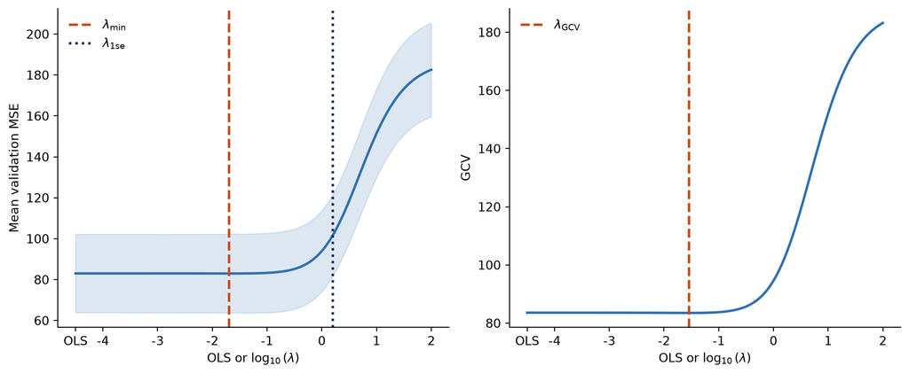

Training-only penalty selection by ten-fold cross-validation and GCV.

Table 4: Penalties selected without using final-test responses

| selection rule | lambda |
| --- | --- |
| CV minimum | 0.01995 |
| One SE | 1.58489 |
| GCV | 0.02818 |

```python
fold_levels = np.sort(np.unique(folds))
fold_mse = np.empty((len(fold_levels), len(lambda_grid)))

for k, fold in enumerate(fold_levels):
    validation = folds == fold
    X_fold_train_raw = X_train_raw[~validation]
    X_fold_validation_raw = X_train_raw[validation]
    y_fold_train = y_train[~validation]
    y_fold_validation = y_train[validation]

    x_bar = X_fold_train_raw.mean(axis=0)
    X_centered = X_fold_train_raw - x_bar
    scales = np.sqrt(np.mean(X_centered**2, axis=0))
    X_fold_train = X_centered / scales
    X_fold_validation = (X_fold_validation_raw - x_bar) / scales

    y_bar = y_fold_train.mean()
    y_centered = y_fold_train - y_bar
    n_fold, p_fold = X_fold_train.shape
    gram = X_fold_train.T @ X_fold_train
    rhs = X_fold_train.T @ y_centered

    for ell, lam in enumerate(lambda_grid):
        beta_hat = np.linalg.solve(
            gram + n_fold * lam * np.eye(p_fold),
            rhs,
        )
        y_hat_validation = y_bar + X_fold_validation @ beta_hat
        fold_mse[k, ell] = np.mean(
            (y_fold_validation - y_hat_validation) ** 2
        )

cv_mean = fold_mse.mean(axis=0)
cv_se = fold_mse.std(axis=0, ddof=1) / np.sqrt(len(fold_levels))
min_index = int(np.argmin(cv_mean))
lambda_min = lambda_grid[min_index]
one_se_limit = cv_mean[min_index] + cv_se[min_index]
lambda_1se = lambda_grid[cv_mean <= one_se_limit].max()

# GCV uses one preprocessing transformation estimated from all training rows.
x_bar = X_train_raw.mean(axis=0)
X_centered = X_train_raw - x_bar
scales = np.sqrt(np.mean(X_centered**2, axis=0))
X_standardized = X_centered / scales
y_bar = y_train.mean()
y_centered = y_train - y_bar
n_train, p_train = X_standardized.shape
gram = X_standardized.T @ X_standardized
rhs = X_standardized.T @ y_centered
d = np.linalg.svd(X_standardized, compute_uv=False)

gcv = np.empty(len(lambda_grid))
df_eff_path = np.empty(len(lambda_grid))
for ell, lam in enumerate(lambda_grid):
    beta_hat = np.linalg.solve(
        gram + n_train * lam * np.eye(p_train),
        rhs,
    )
    y_hat = y_bar + X_standardized @ beta_hat
    df_eff_path[ell] = 1 + np.sum(d**2 / (d**2 + n_train * lam))
    mse_train = np.mean((y_train - y_hat) ** 2)
    gcv[ell] = mse_train / (1 - df_eff_path[ell] / n_train) ** 2

lambda_gcv = lambda_grid[int(np.argmin(gcv))]

# Give OLS its own plotting position immediately left of the log-scale grid.
positive = lambda_grid > 0
log_positive = np.log10(lambda_grid[positive])
ols_position = log_positive.min() - 0.5
plot_position = np.full(len(lambda_grid), ols_position)
plot_position[positive] = log_positive


def penalty_position(lam):
    return ols_position if lam == 0 else np.log10(lam)


fig, axes = plt.subplots(1, 2, figsize=(10.5, 4.4))
axes[0].fill_between(
    plot_position, cv_mean - cv_se, cv_mean + cv_se,
    color="#2F6FB3", alpha=0.16,
)
axes[0].plot(plot_position, cv_mean, color="#2F6FB3", linewidth=2)
axes[0].axvline(
    penalty_position(lambda_min), color="#C84A16", linestyle="--",
    linewidth=2, label=r"$\lambda_{\min}$",
)
axes[0].axvline(
    penalty_position(lambda_1se), color="#13294B", linestyle=":",
    linewidth=2, label=r"$\lambda_{\mathrm{1se}}$",
)
axes[0].set(xlabel=r"OLS or $\log_{10}(\lambda)$", ylabel="Mean validation MSE")
axes[0].legend(frameon=False)

axes[1].plot(plot_position, gcv, color="#2F6FB3", linewidth=2)
axes[1].axvline(
    penalty_position(lambda_gcv), color="#C84A16", linestyle="--",
    linewidth=2, label=r"$\lambda_{\mathrm{GCV}}$",
)
axes[1].set(xlabel=r"OLS or $\log_{10}(\lambda)$", ylabel="GCV")
axes[1].legend(frameon=False)

for ax in axes:
    ticks = np.r_[ols_position, np.arange(-4, 3)]
    ax.set_xticks(ticks, ["OLS", "-4", "-3", "-2", "-1", "0", "1", "2"])
    ax.spines[["top", "right"]].set_visible(False)

fig.tight_layout()
plt.show()

selection_summary = pd.DataFrame(
    {
        "selection rule": ["CV minimum", "One SE", "GCV"],
        "lambda": [lambda_min, lambda_1se, lambda_gcv],
    }
)
display(
    selection_summary.style
    .format({"lambda": "{:.5f}"})
    .hide(axis="index")
    .set_caption("Penalties selected without using final-test responses")
)
```

The cross-validation curve is minimized at $\lambda_{\min}=0.01995$. The one-SE rule accepts every model whose mean validation MSE is within one standard error of this minimum, then deliberately chooses the strongest eligible regularization. That is why it can select the much larger value $\lambda_{\mathrm{1se}}=1.58489$ even though the curve is minimized near $0.02$.

#### b.

For the full training design, the calculation in the preceding code uses

$$\operatorname{df}_{\mathrm{eff}}(\lambda)
=
1+\sum_{j=1}^{6}\frac{d_j^2}{d_j^2+332\lambda}$$

inside the stated GCV formula. Training MSE by itself tends to reward flexible fits. The denominator inflates that error according to the model’s effective degrees of freedom, correcting some of the training optimism without constructing explicit validation folds. The resulting curve is minimized at $\lambda_{\mathrm{GCV}}=0.02818$, close to the ten-fold CV minimizer.

#### c.

At this point all three data-dependent penalties are fixed from the training data. The next cell is the first place where the final-test responses are extracted.

**Show the workflow**

```python
selected = pd.DataFrame(
    {
        "model": ["OLS", "CV minimum", "One SE", "GCV"],
        "lambda": [0.0, lambda_min, lambda_1se, lambda_gcv],
    }
)

# The test responses are accessed only after all choices above have been fixed.
y_test = course_data.loc[~is_train, "price"].to_numpy(float)
selected["effective df"] = np.nan
selected["training MSE"] = np.nan
selected["test MSE"] = np.nan

for row, lam in enumerate(selected["lambda"]):
    fit = fit_ridge(X_train_raw, y_train, lam, X_test_raw)
    selected.loc[row, "effective df"] = fit["df_eff"]
    selected.loc[row, "training MSE"] = np.mean(
        (y_train - fit["y_hat"]) ** 2
    )
    selected.loc[row, "test MSE"] = np.mean(
        (y_test - fit["y_hat_new"]) ** 2
    )

display(
    selected.style
    .format(
        {
            "lambda": "{:.5f}",
            "effective df": "{:.3f}",
            "training MSE": "{:.3f}",
            "test MSE": "{:.3f}",
        }
    )
    .hide(axis="index")
    .set_caption("Final full-training fits and held-out test performance")
)
```

Table 5: Final full-training fits and held-out test performance

| model | lambda | effective df | training MSE | test MSE |
| --- | --- | --- | --- | --- |
| OLS | 0.00000 | 7.000 | 80.094 | 66.322 |
| CV minimum | 0.01995 | 6.773 | 80.135 | 66.000 |
| One SE | 1.58489 | 3.033 | 100.374 | 81.200 |
| GCV | 0.02818 | 6.689 | 80.171 | 65.903 |

OLS uses all $7$ effective degrees of freedom and has training/test MSE $80.094/66.322$. The CV-minimum and GCV fits use only mild shrinkage: their effective degrees of freedom are $6.773$ and $6.689$, and their test MSE values are $66.000$ and $65.903$. A difference of $0.097$ on this one test split is too small to support a meaningful claim that one rule is better. GCV is also not an independent test result; it is a training-data estimate that adjusts residual error using effective degrees of freedom.

The one-SE fit is much simpler, with effective degrees of freedom $3.033$, and its training/test MSE rises to $100.374/81.200$. That poor result on one test split does not invalidate the one-SE rule: the rule intentionally gives up some estimated accuracy for stronger regularization, and another sample could rank it differently. Finally, I cannot choose GCV just because its row has the smallest displayed test MSE. Doing so would turn the test set into another validation set and make the winning test error too optimistic. The honest use of this table is to assess selection rules that were fixed before the test responses were viewed.

## Reference

The real-estate data come from I-Cheng Yeh’s [Real Estate Valuation dataset](https://archive.ics.uci.edu/dataset/477/real%2Bestate%2Bvaluation%2Bda) in the UCI Machine Learning Repository. The distributed data retain the original observations and add only the course train-test and fold assignments.

## explain-to-me skill

```markdown
---
name: explain-to-me
description: Use only when I explicitly ask to understand, rather than solve, a STAT 432 homework question.
---

# Goal

Help me turn a homework prompt into a manageable plan while leaving the actual solution to me.

# Response guide

- Read the whole question before explaining it.
- State the main goal, then list the deliverables for each part of a multi-part question.
- Clarify important symbols using the notation in the prompt.
- When useful, name one relevant section from [Ridge Regression: Stability Through Shrinkage](https://teazrq.github.io/stat432rpy/topics/ridge-regression/ridge-regression.html) or [From a Penalized Objective to a Fitted Ridge Model](https://teazrq.github.io/stat432rpy/topics/ridge-regression/optimization-and-cross-validation.html), and say why it helps. If the page cannot be checked, do not guess a section name.
- Suggest one reasonable first step and finish by asking what is still unclear.
- Stop before doing calculations or derivations, writing solution code, or stating a final answer.
```